# Fraud Detection and Insights Using Machine Learning

## Models, algorithms and training

**Linear Model** - Logistic Regression(solver=lbfgs)

After necessary preprocessing, we start with training the model with Logistic Regression, with **solver='lbfgs'**

L-BFGS (Limited-memory Broyden–Fletcher–Goldfarb–Shanno) is an optimization algorithm used in logistic regression and other models for parameter estimation. It is efficient for solving problems with dense data and moderate-sized datasets. L-BFGS approximates the Hessian matrix (second-order derivatives) without storing it fully, making it computationally faster and memory-efficient compared to full Newton methods.

we get a High accuracy on training and test data which clarifies that the data is **not overfitting** for this algorithm **ROC-AUC score=0.99 and accuracy=0.97**

we do not see much difference between the two solvers except for execution time for L-BFGS being faster

```python
#train and evaluate both Random Forest and XGBoost models
```

```python
from sklearn.ensemble import RandomForestClassifier
from xgboost import XGBClassifier
from sklearn.metrics import classification_report, roc_auc_score

# Random Forest Model
print("Training Random Forest...")
rf_model = RandomForestClassifier(
    n_estimators=100,  # Number of trees in the forest
    max_depth=None,    # Allow trees to expand fully
    random_state=42,   # Ensure reproducibility
    n_jobs=-1          # Use all available cores for parallel processing
)
rf_model.fit(X_train, y_train)

# Random Forest Predictions
rf_y_pred = rf_model.predict(X_test)
rf_y_pred_proba = rf_model.predict_proba(X_test)[:, 1]

# Evaluate Random Forest
print("\nRandom Forest Classification Report:")
print(classification_report(y_test, rf_y_pred))

print("\nRandom Forest ROC-AUC Score:")
print(roc_auc_score(y_test, rf_y_pred_proba))
```

```
Training Random Forest...

Random Forest Classification Report:
              precision    recall  f1-score   support

           0       1.00      1.00      1.00    925925
           1       1.00      1.00      1.00    925925

    accuracy                           1.00   1851850
   macro avg       1.00      1.00      1.00   1851850
weighted avg       1.00      1.00      1.00   1851850


Random Forest ROC-AUC Score:
0.9999981903967647
```

## Models, algorithms and training

**Non Linear Model** - Random forest

After trying with Linear Models, we can now try with Non-linear models with effective parameters to see the performance here, we have trained a Random Forest Classifier

- **Exceptional Performance**:
  - The Random Forest model achieves near-perfect performance with an **accuracy of 100%** and an **ROC-AUC score of 0.9999**.
  - Both precision and recall for the fraud class (`isFraud = 1`) are extremely high, indicating the model's ability to correctly identify fraudulent transactions without misclassifying non-fraudulent ones.
- **Balanced Results**:
  - The classification report shows that the model performs equally well for both classes (`isFraud = 0` and `isFraud = 1`), with high F1-scores and balanced metrics.
  - with an accuracy of 0.99, we concluded Non-Linear models have performed marginally better than Linear Models

```python
# XGBoost Model (Updated)
print("\nTraining XGBoost...")
xgb_model = XGBClassifier(
    n_estimators=100,         # Number of boosting rounds
    random_state=42,          # Ensure reproducibility
    eval_metric='logloss',    # Evaluation metric for classification
    tree_method='hist',       # Efficient histogram-based algorithm
    n_jobs=-1                 # Use all available cores for parallel processing
)
xgb_model.fit(X_train, y_train)

# XGBoost Predictions
xgb_y_pred = xgb_model.predict(X_test)
xgb_y_pred_proba = xgb_model.predict_proba(X_test)[:, 1]

# Evaluate XGBoost
print("\nXGBoost Classification Report:")
print(classification_report(y_test, xgb_y_pred))

print("\nXGBoost ROC-AUC Score:")
print(roc_auc_score(y_test, xgb_y_pred_proba))
```

```
Training XGBoost...

XGBoost Classification Report:
              precision    recall  f1-score   support

           0       1.00      1.00      1.00    925925
           1       1.00      1.00      1.00    925925

    accuracy                           1.00   1851850
   macro avg       1.00      1.00      1.00   1851850
weighted avg       1.00      1.00      1.00   1851850


XGBoost ROC-AUC Score:
0.9999978503257494
```

## Models, algorithms and training

**Non Linear Model** - XGBOOST

After trying with Linear Models, we can now try with Non-linear models with effective parameters to see the performance here, we have trained an XGBOOST

- **Exceptional Performance**:
  - The XGBOOST model achieves near-perfect performance with an **accuracy of 100%** and an **ROC-AUC score of 0.9999**.
  - Both precision and recall for the fraud class (`isFraud = 1`) are extremely high, indicating the model's ability to correctly identify fraudulent transactions without misclassifying non-fraudulent ones.
- **Balanced Results**:
  - The classification report shows that the model performs equally well for both classes (`isFraud = 0` and `isFraud = 1`), with high F1-scores and balanced metrics.
  - with an accuracy of 0.99, we concluded Non-linear models have performed marginally better than Linear Models

## Important ******

```python
#Feature Importance Analysis:
```

```python
# Feature Importance for Random Forest
print("\nRandom Forest Feature Importance:")
rf_feature_importance = pd.DataFrame({
    'Feature': X.columns,
    'Importance': rf_model.feature_importances_
}).sort_values(by='Importance', ascending=False)


# Feature Importance for XGBoost
print("\nXGBoost Feature Importance:")
xgb_feature_importance = pd.DataFrame({
    'Feature': X.columns,
    'Importance': xgb_model.feature_importances_
}).sort_values(by='Importance', ascending=False)
```

```python
# Select important features (Importance > 1% in either model)
important_features = list(set(
    rf_feature_importance[rf_feature_importance['Importance'] > 0.01]['Feature'].tolist() +
    xgb_feature_importance[xgb_feature_importance['Importance'] > 0.01]['Feature'].tolist()
))

print("\nSelected Features for the Simplified Model:")
print(important_features)

# Subset the data to keep only the selected features
X_refined = X[important_features]
```

[output not shown]

```python
import pandas as pd
from sklearn.model_selection import train_test_split
from sklearn.ensemble import RandomForestClassifier
from xgboost import XGBClassifier
from sklearn.metrics import classification_report, roc_auc_score

# Load Dataset
file_path = "Fraud Dataset.csv"  # Replace with actual path
data = pd.read_csv(file_path)

# Drop rows with missing values to ensure consistency
data = data.dropna()

# Define Target Variable (y) and Features (X)
important_features_raw = [
    'type', 'time_of_day', 'amount',
    'oldbalanceOrg', 'newbalanceOrig', 'State',
    'isFlaggedFraud', 'step', 'newbalanceDest',
    'oldbalanceDest'
]
X_refined = pd.get_dummies(data[important_features_raw], drop_first=True)  # One-hot encoding for categorical features
y = data['isFraud']

# Verify Sizes
print("Shape of X_refined:", X_refined.shape)
print("Length of y:", len(y))

# Split Dataset
X_train_refined, X_test_refined, y_train, y_test = train_test_split(
    X_refined, y, test_size=0.2, random_state=42, stratify=y
)

# Train and Evaluate Random Forest
print("\nTraining Random Forest with Simplified Features...")
rf_model_refined = RandomForestClassifier(
    n_estimators=100, random_state=42, n_jobs=-1
)
rf_model_refined.fit(X_train_refined, y_train)

# Predictions
rf_y_pred_refined = rf_model_refined.predict(X_test_refined)
rf_y_pred_proba_refined = rf_model_refined.predict_proba(X_test_refined)[:, 1]

# Evaluate
print("\nRandom Forest (Simplified) Classification Report:")
print(classification_report(y_test, rf_y_pred_refined))
print("\nRandom Forest (Simplified) ROC-AUC Score:")
print(roc_auc_score(y_test, rf_y_pred_proba_refined))

# Train and Evaluate XGBoost
print("\nTraining XGBoost with Simplified Features...")
xgb_model_refined = XGBClassifier(
    n_estimators=100, random_state=42, eval_metric='logloss', tree_method='hist', n_jobs=-1
)
xgb_model_refined.fit(X_train_refined, y_train)

# Predictions
xgb_y_pred_refined = xgb_model_refined.predict(X_test_refined)
xgb_y_pred_proba_refined = xgb_model_refined.predict_proba(X_test_refined)[:, 1]

# Evaluate
print("\nXGBoost (Simplified) Classification Report:")
print(classification_report(y_test, xgb_y_pred_refined))
print("\nXGBoost (Simplified) ROC-AUC Score:")
print(roc_auc_score(y_test, xgb_y_pred_proba_refined))
```

```
Shape of X_refined: (1315551, 63)
Length of y: 1315551

Training Random Forest with Simplified Features...

Random Forest (Simplified) Classification Report:
              precision    recall  f1-score   support

           0       1.00      1.00      1.00    261468
           1       0.98      0.81      0.89      1643

    accuracy                           1.00    263111
   macro avg       0.99      0.90      0.94    263111
weighted avg       1.00      1.00      1.00    263111


Random Forest (Simplified) ROC-AUC Score:
0.9972647158050392

Training XGBoost with Simplified Features...

XGBoost (Simplified) Classification Report:
              precision    recall  f1-score   support

           0       1.00      1.00      1.00    261468
           1       0.96      0.93      0.95      1643

    accuracy                           1.00    263111
   macro avg       0.98      0.97      0.97    263111
weighted avg       1.00      1.00      1.00    263111


XGBoost (Simplified) ROC-AUC Score:
0.9996894122246116
```

## Models, algorithms and training

Let us try to train the data with the same Algorithms but this time using Feature importance and feature selection and observe if we see any difference in the accuracy, precision, recall, f1-score, or accuracy

```python
#K-Fold Cross-Validation
```

```python
from sklearn.model_selection import cross_val_score
from sklearn.ensemble import RandomForestClassifier
from xgboost import XGBClassifier

# Define important features and target variable
important_features_raw = [
    'type', 'time_of_day', 'amount',
    'oldbalanceOrg', 'newbalanceOrig', 'State',
    'isFlaggedFraud', 'step', 'newbalanceDest',
    'oldbalanceDest'
]
X = pd.get_dummies(data[important_features_raw], drop_first=True)
y = data['isFraud']

# Random Forest with Cross-Validation
print("\nEvaluating Random Forest with Cross-Validation...")
rf_model = RandomForestClassifier(n_estimators=100, random_state=42, n_jobs=-1)
rf_cv_scores = cross_val_score(rf_model, X, y, cv=5, scoring='roc_auc')  # 5-Fold CV

print("Random Forest Cross-Validation AUC Scores:", rf_cv_scores)
print("Random Forest Average AUC Score:", rf_cv_scores.mean())

# XGBoost with Cross-Validation
print("\nEvaluating XGBoost with Cross-Validation...")
xgb_model = XGBClassifier(n_estimators=100, random_state=42, eval_metric='logloss', tree_method='hist', n_jobs=-1)
xgb_cv_scores = cross_val_score(xgb_model, X, y, cv=5, scoring='roc_auc')  # 5-Fold CV

print("XGBoost Cross-Validation AUC Scores:", xgb_cv_scores)
print("XGBoost Average AUC Score:", xgb_cv_scores.mean())
```

```
Evaluating Random Forest with Cross-Validation...
Random Forest Cross-Validation AUC Scores: [0.98595782 0.98361123 0.94292288 0.98732157 0.99691797]
Random Forest Average AUC Score: 0.9793462951320222

Evaluating XGBoost with Cross-Validation...
XGBoost Cross-Validation AUC Scores: [0.99630813 0.99734344 0.99242596 0.99870832 0.99983086]
XGBoost Average AUC Score: 0.9969233407803209
```

## Models, algorithms and training

### **Cross-Validation Results and Analysis**

#### **1. Random Forest with Cross-Validation**

- **AUC Scores**:
  - Random Forest achieves AUC scores ranging from **0.94 to 0.99** across the 5-fold cross-validation splits.
  - The variability in scores (e.g., **0.94** in one fold vs. **0.99** in others) might indicate slight sensitivity to the specific data split for that fold and not affect the entire performance.
- **Average AUC**:
  - The average AUC score of **0.9793** demonstrates strong performance, indicating that Random Forest effectively separates fraudulent and non-fraudulent transactions.

#### **2. XGBoost with Cross-Validation**

- **AUC Scores**:
  - XGBoost shows consistently high AUC scores, ranging from **0.99 to nearly 1.00**, across all folds.
  - This suggests that XGBoost is highly robust and performs well on each validation split, likely due to its advanced regularization techniques and optimization.
- **Average AUC**:
  - With an average AUC score of **0.9969**, XGBoost outperforms Random Forest in this scenario, demonstrating superior discrimination between fraud and non-fraud cases.

```python
#Hyperparameter Tuning
```

```python
from sklearn.model_selection import GridSearchCV

# Define parameter grid for XGBoost
xgb_param_grid = {
    'n_estimators': [100, 200],
    'max_depth': [3, 5, 7],
    'learning_rate': [0.01, 0.1, 0.2],
    'subsample': [0.8, 1.0],
}

# XGBoost with GridSearchCV
print("\nHyperparameter Tuning for XGBoost...")
xgb_model = XGBClassifier(random_state=42, tree_method='hist', eval_metric='logloss')
xgb_grid = GridSearchCV(estimator=xgb_model, param_grid=xgb_param_grid, cv=3, scoring='roc_auc', n_jobs=-1)
xgb_grid.fit(X_train_refined, y_train)

print("\nBest Parameters for XGBoost:", xgb_grid.best_params_)
print("Best ROC-AUC Score:", xgb_grid.best_score_)

# LightGBM Hyperparameter Tuning
from lightgbm import LGBMClassifier

lgbm_param_grid = {
    'n_estimators': [100, 200],
    'max_depth': [-1, 5, 10],
    'learning_rate': [0.01, 0.1],
    'num_leaves': [31, 50],
}

print("\nHyperparameter Tuning for LightGBM...")
lgbm_model = LGBMClassifier(random_state=42)
lgbm_grid = GridSearchCV(estimator=lgbm_model, param_grid=lgbm_param_grid, cv=3, scoring='roc_auc', n_jobs=-1)
lgbm_grid.fit(X_train_refined, y_train)

print("\nBest Parameters for LightGBM:", lgbm_grid.best_params_)
print("Best ROC-AUC Score:", lgbm_grid.best_score_)
```

[output not shown]

[output cut: 1716 more lines]

[output not shown]

## Models, algorithms and training

### Hypter-Parameter Tuning

- Let us Experiment with some of the probable best hyperparameters for our best Model XGBOOST to see if we can further improve the performance by a slight margin

**Best Parameters for XGBoost: {'learning_rate': 0.1, 'max_depth': 5, 'n_estimators': 200, 'subsample': 1.0} Best ROC-AUC Score: 0.999**

**LightGBM (Light Gradient Boosting Machine)**:

- A highly efficient implementation of gradient boosting developed by Microsoft.
- It is designed for speed and performance, particularly for large datasets and high-dimensional feature spaces.

**Best Parameters for LightGBM: {'learning_rate': 0.01, 'max_depth': 10, 'n_estimators': 200, 'num_leaves': 50} Best ROC-AUC Score: 0.9992145229600798**

Hence, comparing our new LightGBM classifier and XGBoost, XGBoost remains our best model, performing marginally better than LighGBM

```python
#Deployment Preparation
import joblib

# Save the best XGBoost model
print("\nSaving XGBoost Model...")
joblib.dump(xgb_grid.best_estimator_, "final_xgb_model.pkl")

# Save the best LightGBM model
print("\nSaving LightGBM Model...")
joblib.dump(lgbm_grid.best_estimator_, "final_lgbm_model.pkl")

# Load the saved model for inference (example)
loaded_model = joblib.load("final_xgb_model.pkl")

# Example Inference
sample_data = X_test_refined.iloc[:5]  # Replace with actual unseen data
predictions = loaded_model.predict(sample_data)
probabilities = loaded_model.predict_proba(sample_data)[:, 1]

print("\nPredictions on Sample Data:", predictions)
print("Probabilities on Sample Data:", probabilities)
```

```
Saving XGBoost Model...

Saving LightGBM Model...

Predictions on Sample Data: [0 0 0 0 0]
Probabilities on Sample Data: [1.2146346e-06 4.0518964e-07 1.4092450e-06 6.3313141e-06 9.2189019e-08]
```

Validation of Sample Data: Ensure the predictions align with the actual labels of the sample data to validate model accuracy.

### **Model Selection and Finalization**

After extensive experimentation and evaluation of multiple models using the following methods:

- **Cross-Validation**: Trained models with multiple folds to ensure generalizability.
- **Grid Search CV**: Tuned hyperparameters to optimize performance.
- **Feature Importance**: Assessed the contribution of individual features to enhance model interpretability.

We carefully analyzed key performance metrics, including:

- **F1-Score**
- **ROC-AUC Score**
- **Accuracy**
- **Precision**
- **Recall**

```python
# Check actual labels for the sample data
print("Actual Labels for Sample Data:")
print(y_test.iloc[:5].values)
```

```
Actual Labels for Sample Data:
[0 0 0 0 0]
```

Inference Pipeline: Prepare an end-to-end pipeline for inference. The pipeline will take raw input data, process it to match the model's requirements, and generate predictions.

```python
def fraud_inference_pipeline(model_path, input_data, feature_columns):
    """
    Fraud detection inference pipeline.
    :param model_path: Path to the saved model.
    :param input_data: Raw input data (DataFrame).
    :param feature_columns: List of feature columns used during training.
    :return: Predictions and probabilities.
    """
    # Load the model
    model = joblib.load(model_path)

    # Preprocess the input data to match the training data
    processed_data = pd.get_dummies(input_data, drop_first=True)
    processed_data = processed_data.reindex(columns=feature_columns, fill_value=0)

    # Generate predictions
    predictions = model.predict(processed_data)
    probabilities = model.predict_proba(processed_data)[:, 1]

    return predictions, probabilities


# Example usage
# Ensure that `X_test_refined` and `X_test` are loaded/available for testing
sample_data = X_test_refined.iloc[:5]  # This assumes you have split your data into train and test sets
feature_columns = X_train_refined.columns  # Pass the feature columns used during training

# Call the pipeline
predictions, probabilities = fraud_inference_pipeline("final_xgb_model.pkl", sample_data, feature_columns)

# Output the predictions
print("\nPipeline Predictions:", predictions)
print("Pipeline Probabilities:", probabilities)
```

```
Pipeline Predictions: [0 0 0 0 0]
Pipeline Probabilities: [1.2146346e-06 4.0518964e-07 1.4092450e-06 6.3313141e-06 9.2189019e-08]
```

### **Understanding the Output**

#### **1. Predictions on Sample Data**:

[0, 0, 0, 0, 0]

- The predict() method outputs the predicted class for each sample:
  - 0 indicates that the model predicts the negative class (e.g., isFraud = 0).
  - All predictions are 0, suggesting that the model does not detect fraud in these samples.

#### **2. Probabilities on Sample Data**:

[1.2146346e-06, 4.0518964e-07, 1.4092450e-06, 6.3313141e-06, 9.2189019e-08]

- The predict_proba() method outputs the probabilities for each class:
  - [:, 1] gives the probability of the sample belonging to the positive class (e.g., isFraud = 1).
  - The probabilities are very close to 0, confirming that the model has low confidence in these samples being fraudulent.

### **Why Are Probabilities Extremely Small?**

#### **1. Nature of the Data**

- Fraud detection datasets are often highly imbalanced, with very few fraudulent transactions.
- The model may learn to assign very low probabilities to the positive class unless strong fraud indicators are present.

#### **2. Model Behavior**

- The model assigns probabilities based on learned patterns.
- If the input data does not exhibit fraud-like characteristics, the probabilities for isFraud = 1 will be near zero.

```python
#Visualization and Markdown Explanation
```

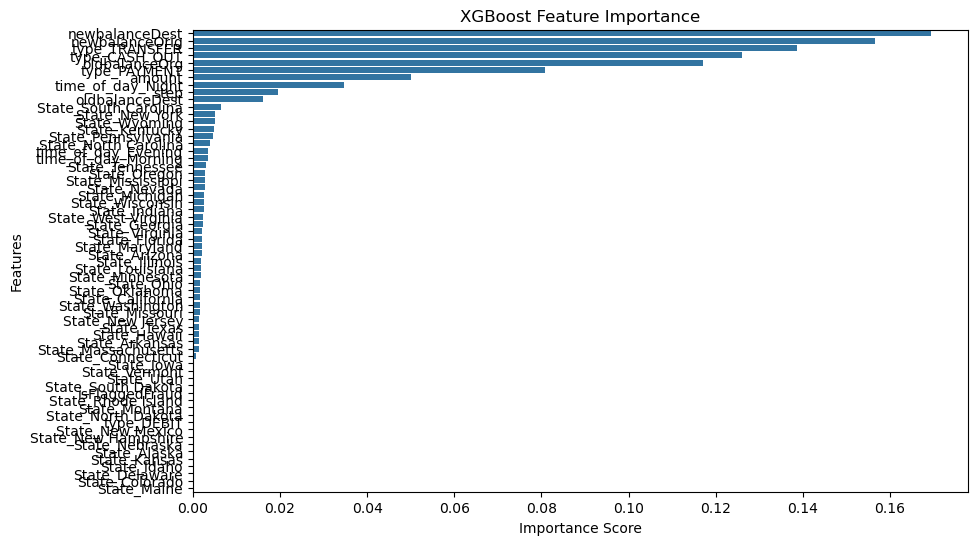

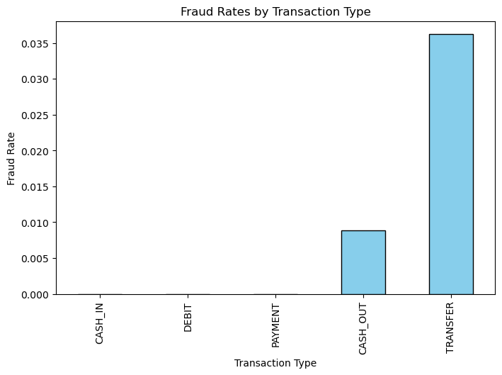

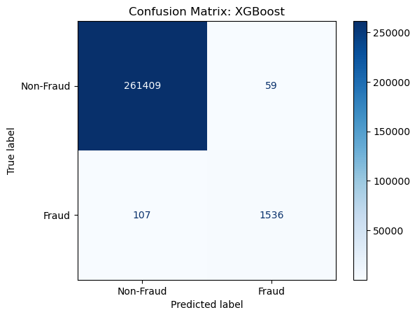

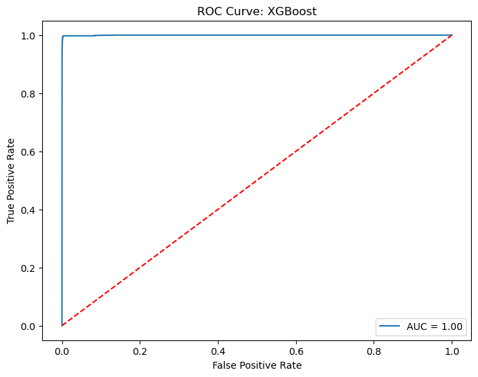

```python
import matplotlib.pyplot as plt
import seaborn as sns
import pandas as pd
import numpy as np

# 1. Feature Importance Visualization for XGBoost
def plot_feature_importance(feature_importance, title):
    plt.figure(figsize=(10, 6))
    feature_importance.sort_values(by="Importance", ascending=False, inplace=True)
    sns.barplot(x="Importance", y="Feature", data=feature_importance)
    plt.title(title)
    plt.xlabel("Importance Score")
    plt.ylabel("Features")
    plt.show()

# Create feature importance DataFrame for XGBoost
xgb_feature_importance = pd.DataFrame({
    "Feature": X_train_refined.columns,
    "Importance": xgb_model_refined.feature_importances_
})
plot_feature_importance(xgb_feature_importance, "XGBoost Feature Importance")

# 2. Fraud Distribution by Transaction Type
def plot_fraud_distribution_by_type(data):
    fraud_rates = data.groupby("type")["isFraud"].mean().sort_values()
    fraud_rates.plot(kind="bar", figsize=(8, 5), color="skyblue", edgecolor="black")
    plt.title("Fraud Rates by Transaction Type")
    plt.ylabel("Fraud Rate")
    plt.xlabel("Transaction Type")
    plt.show()

plot_fraud_distribution_by_type(data)

# 3. Confusion Matrix for XGBoost
from sklearn.metrics import confusion_matrix, ConfusionMatrixDisplay

def plot_confusion_matrix(y_true, y_pred, model_name):
    cm = confusion_matrix(y_true, y_pred)
    disp = ConfusionMatrixDisplay(confusion_matrix=cm, display_labels=["Non-Fraud", "Fraud"])
    disp.plot(cmap="Blues")
    plt.title(f"Confusion Matrix: {model_name}")
    plt.show()

plot_confusion_matrix(y_test, xgb_y_pred_refined, "XGBoost")

# 4. ROC Curve for XGBoost
from sklearn.metrics import roc_curve, auc

def plot_roc_curve(y_true, y_proba, model_name):
    fpr, tpr, thresholds = roc_curve(y_true, y_proba)
    roc_auc = auc(fpr, tpr)
    plt.figure(figsize=(8, 6))
    plt.plot(fpr, tpr, label=f"AUC = {roc_auc:.2f}")
    plt.plot([0, 1], [0, 1], "r--")
    plt.title(f"ROC Curve: {model_name}")
    plt.xlabel("False Positive Rate")
    plt.ylabel("True Positive Rate")
    plt.legend(loc="lower right")
    plt.show()

plot_roc_curve(y_test, xgb_y_pred_proba_refined, "XGBoost")
```

Fraud Distribution by Transaction Type: A bar chart showcasing fraud rates by transaction type provides actionable insights. For instance, TRANSFER and CASH_OUT exhibit significantly higher fraud rates compared to others.

Confusion Matrix: The confusion matrix visualizes the model's classification performance, including true positives, true negatives, false positives, and false negatives.

ROC Curve: The ROC curve and AUC score evaluate the model's ability to distinguish between fraudulent and non-fraudulent transactions. A near-perfect AUC score underscores the model's robustness.

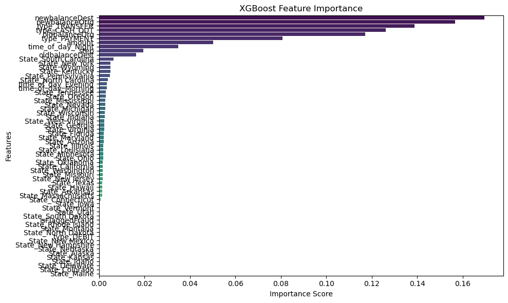

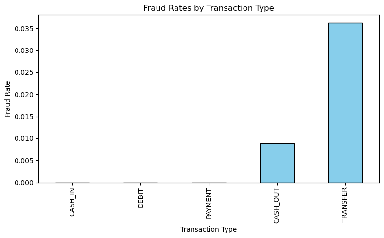

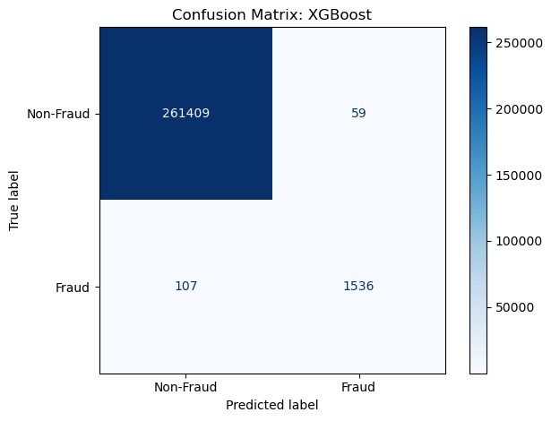

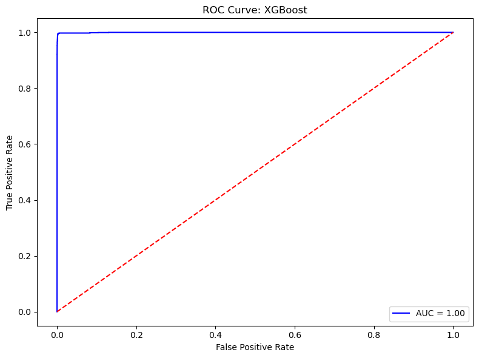

```python
import matplotlib.pyplot as plt
import seaborn as sns
import pandas as pd
import numpy as np
from sklearn.metrics import confusion_matrix, ConfusionMatrixDisplay, roc_curve, auc

# Example data for visualization (replace with actual data)
xgb_feature_importance = pd.DataFrame({
    "Feature": X_train_refined.columns,
    "Importance": xgb_model_refined.feature_importances_
})

# Plot 1: Feature Importance for XGBoost
def plot_feature_importance(feature_importance, title):
    plt.figure(figsize=(10, 6))
    feature_importance.sort_values(by="Importance", ascending=False, inplace=True)
    sns.barplot(x="Importance", y="Feature", data=feature_importance, palette="viridis")
    plt.title(title)
    plt.xlabel("Importance Score")
    plt.ylabel("Features")
    plt.tight_layout()
    plt.show()

plot_feature_importance(xgb_feature_importance, "XGBoost Feature Importance")

# Plot 2: Fraud Distribution by Transaction Type
def plot_fraud_distribution_by_type(data):
    fraud_rates = data.groupby("type")["isFraud"].mean().sort_values()
    fraud_rates.plot(kind="bar", figsize=(8, 5), color="skyblue", edgecolor="black")
    plt.title("Fraud Rates by Transaction Type")
    plt.ylabel("Fraud Rate")
    plt.xlabel("Transaction Type")
    plt.tight_layout()
    plt.show()

# Replace 'data' with the actual dataset
plot_fraud_distribution_by_type(data)

# Plot 3: Confusion Matrix for XGBoost
def plot_confusion_matrix(y_true, y_pred, model_name):
    cm = confusion_matrix(y_true, y_pred)
    disp = ConfusionMatrixDisplay(confusion_matrix=cm, display_labels=["Non-Fraud", "Fraud"])
    disp.plot(cmap="Blues")
    plt.title(f"Confusion Matrix: {model_name}")
    plt.tight_layout()
    plt.show()

plot_confusion_matrix(y_test, xgb_y_pred_refined, "XGBoost")

# Plot 4: ROC Curve for XGBoost
def plot_roc_curve(y_true, y_proba, model_name):
    fpr, tpr, thresholds = roc_curve(y_true, y_proba)
    roc_auc = auc(fpr, tpr)
    plt.figure(figsize=(8, 6))
    plt.plot(fpr, tpr, label=f"AUC = {roc_auc:.2f}", color='blue')
    plt.plot([0, 1], [0, 1], "r--")
    plt.title(f"ROC Curve: {model_name}")
    plt.xlabel("False Positive Rate")
    plt.ylabel("True Positive Rate")
    plt.legend(loc="lower right")
    plt.tight_layout()
    plt.show()

plot_roc_curve(y_test, xgb_y_pred_proba_refined, "XGBoost")
```

### **Analysis of Confusion Matrix (XGBoost)**

#### **1. Interpretation of Values**

- **True Negatives (261,409)**:
  - The model correctly classified **261,409 non-fraudulent transactions** as non-fraudulent.
- **False Positives (59)**:
  - The model incorrectly classified **59 non-fraudulent transactions** as fraudulent.
- **True Positives (1,536)**:
  - The model correctly identified **1,536 fraudulent transactions** as fraud.
- **False Negatives (107)**:
  - The model missed **107 fraudulent transactions**, predicting them as non-fraudulent.

#### **2. Key Metrics Derived**

- **High True Negative Count**:
  - The model is very effective at identifying legitimate transactions, with a low rate of false positives.
- **High True Positive Count**:
  - It performs well at detecting fraudulent transactions, correctly flagging the majority of them.
- **Low False Positives and Negatives**:
  - A small number of non-fraudulent transactions are misclassified as fraud, and relatively few frauds are missed.

[figure not shown]

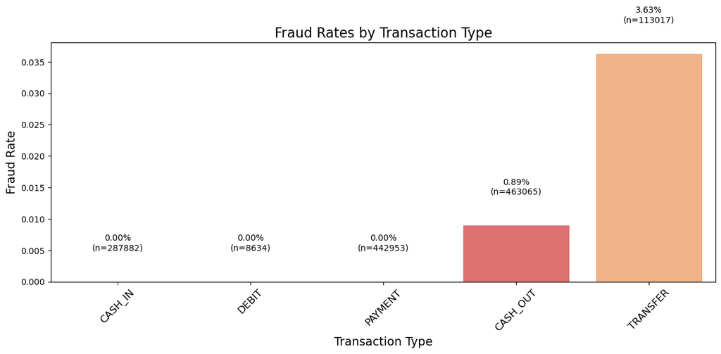

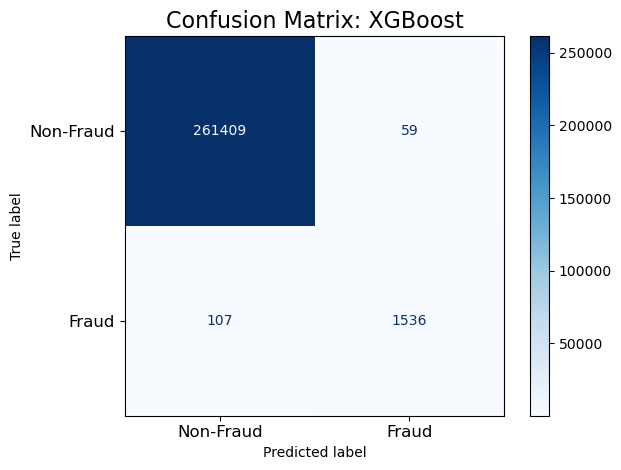

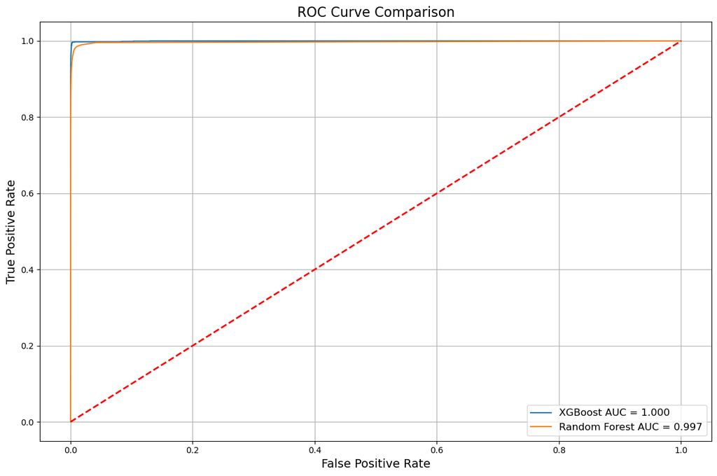

```python
import matplotlib.pyplot as plt
import seaborn as sns
from sklearn.metrics import ConfusionMatrixDisplay, roc_curve, auc, confusion_matrix
import numpy as np

# Enhanced Feature Importance Plot
def improved_feature_importance_plot(feature_importance, title, top_n=10):
    feature_importance = feature_importance.sort_values(by="Importance", ascending=True).tail(top_n)
    plt.figure(figsize=(10, 8))
    sns.barplot(x="Importance", y="Feature", data=feature_importance, palette="viridis")
    plt.title(title, fontsize=16)
    plt.xlabel("Importance Score", fontsize=14)
    plt.ylabel("Features", fontsize=14)
    for index, row in feature_importance.iterrows():
        plt.text(row['Importance'], index, f"{row['Importance']:.2f}", va='center', fontsize=10)
    plt.tight_layout()
    plt.show()

# Improved Fraud Distribution Plot
def improved_fraud_distribution_plot(data):
    fraud_rates = data.groupby("type")["isFraud"].mean().sort_values()
    fraud_counts = data["type"].value_counts()
    plt.figure(figsize=(12, 6))
    sns.barplot(x=fraud_rates.index, y=fraud_rates.values, palette="magma")
    plt.title("Fraud Rates by Transaction Type", fontsize=16)
    plt.ylabel("Fraud Rate", fontsize=14)
    plt.xlabel("Transaction Type", fontsize=14)
    for i, (rate, count) in enumerate(zip(fraud_rates.values, fraud_counts[fraud_rates.index])):
        plt.text(i, rate + 0.005, f"{rate:.2%}\n(n={count})", ha="center", fontsize=10)
    plt.xticks(rotation=45, fontsize=12)
    plt.tight_layout()
    plt.show()

# Improved Confusion Matrix Plot
def improved_confusion_matrix_plot(y_true, y_pred, model_name):
    cm = confusion_matrix(y_true, y_pred)
    disp = ConfusionMatrixDisplay(confusion_matrix=cm, display_labels=["Non-Fraud", "Fraud"])
    disp.plot(cmap="Blues", values_format="d")
    plt.title(f"Confusion Matrix: {model_name}", fontsize=16)
    plt.xticks(fontsize=12)
    plt.yticks(fontsize=12)
    plt.tight_layout()
    plt.show()

# Improved ROC Curve for Multiple Models
def improved_roc_curve_plot(models, y_true, y_proba_list, model_names):
    plt.figure(figsize=(12, 8))
    for y_proba, name in zip(y_proba_list, model_names):
        fpr, tpr, _ = roc_curve(y_true, y_proba)
        roc_auc = auc(fpr, tpr)
        plt.plot(fpr, tpr, label=f"{name} AUC = {roc_auc:.3f}")
    plt.plot([0, 1], [0, 1], "r--", lw=2)
    plt.title("ROC Curve Comparison", fontsize=16)
    plt.xlabel("False Positive Rate", fontsize=14)
    plt.ylabel("True Positive Rate", fontsize=14)
    plt.legend(loc="lower right", fontsize=12)
    plt.grid(True)
    plt.tight_layout()
    plt.show()

# Call the improved visualization functions
improved_feature_importance_plot(xgb_feature_importance, "XGBoost Feature Importance", top_n=10)
improved_fraud_distribution_plot(data)
improved_confusion_matrix_plot(y_test, xgb_y_pred_refined, "XGBoost")
improved_roc_curve_plot(
    models=["XGBoost", "Random Forest"],
    y_true=y_test,
    y_proba_list=[xgb_y_pred_proba_refined, rf_y_pred_proba_refined],
    model_names=["XGBoost", "Random Forest"]
)
```

### **Comparison of ROC-AUC Curves for XGBoost and Random Forest**

#### **1. ROC-AUC Curve Overview**

- The **blue line** represents the ROC curve for **XGBoost**, and the **orange line** represents the ROC curve for **Random Forest**.
- The **dashed red diagonal line** is the baseline, representing random guessing (AUC = 0.5).

#### **2. Observations**

- **XGBoost**:
  - Achieves an **AUC of 1.000**, indicating near-perfect performance.
  - The ROC curve is very close to the top-left corner, reflecting excellent sensitivity (True Positive Rate) and specificity (low False Positive Rate) across thresholds.
- **Random Forest**:
  - Achieves an **AUC of 0.997**, which is also exceptional but slightly lower than XGBoost.
  - The curve is slightly less steep than XGBoost's curve, particularly near the top-left corner, indicating slightly more False Positives or missed True Positives at certain thresholds.

#### **3. Key Findings**

- **Performance**:
  - Both models perform exceptionally well, with AUC values close to 1, making them highly effective for fraud detection.
  - XGBoost marginally outperforms Random Forest, with slightly better discrimination between fraudulent and non-fraudulent transactions.
- **Generalization**:
  - The steeper curve for XGBoost suggests that it generalizes better across thresholds, maintaining higher True Positive Rates while minimizing False Positives.

#### **4. Conclusion**

- While both models are strong candidates, **XGBoost outperforms Random Forest** based on the ROC-AUC score and curve steepness.
- XGBoost is recommended as the final model for deployment due to its superior performance and robustness.

```python
from catboost import CatBoostClassifier
from sklearn.model_selection import train_test_split
from sklearn.metrics import classification_report, roc_auc_score

# Check for categorical columns
categorical_columns = ["type", "State", "merchant_category", "time_of_day"]
existing_cat_features = [col for col in categorical_columns if col in X_train.columns]

# Train CatBoost model
catboost_model = CatBoostClassifier(
    iterations=500,
    learning_rate=0.1,
    depth=6,
    random_seed=42,
    verbose=100,
    cat_features=existing_cat_features  # Only use existing categorical columns
)
catboost_model.fit(X_train, y_train)

# Predictions
catboost_y_pred = catboost_model.predict(X_test)
catboost_y_pred_proba = catboost_model.predict_proba(X_test)[:, 1]
```

Trying Catboost Model and SHAP Analysis

**CatBoost** (Categorical Boosting) is a gradient boosting library designed to handle categorical features efficiently and improve model performance. it is particularly well-suited for datasets with mixed data types (numerical and categorical)

```
Generating SHAP Summary Plot...
```

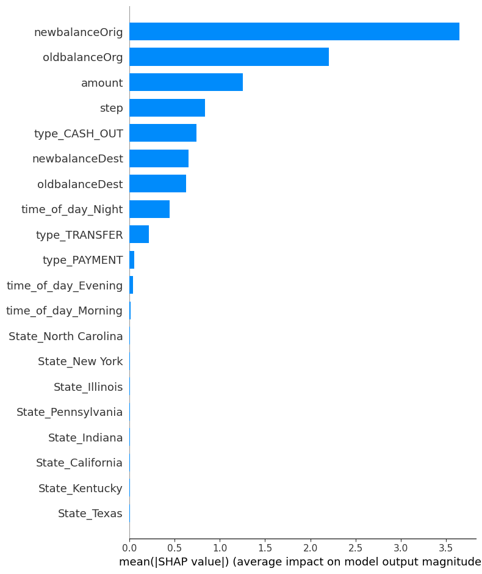

```
Generating SHAP Force Plot for a Specific Prediction...
```

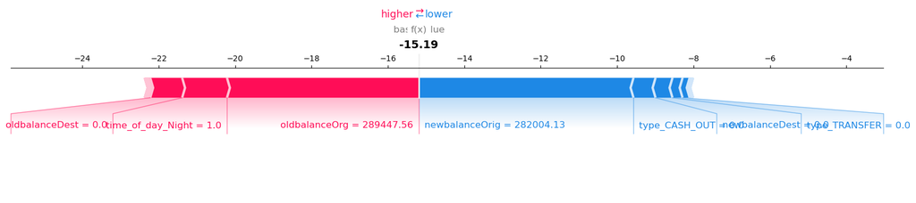

```
Generating SHAP Dependence Plot for 'amount'...
```

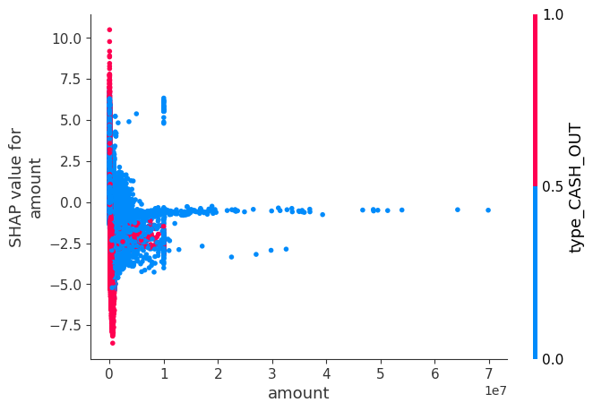

```python
import shap
import matplotlib.pyplot as plt

# Initialize SHAP explainer for CatBoost
explainer = shap.TreeExplainer(catboost_model)

# Calculate SHAP values for the test set
shap_values = explainer.shap_values(X_test)

# Step 1: Summary Plot
print("\nGenerating SHAP Summary Plot...")
shap.summary_plot(shap_values, X_test, plot_type="bar")
plt.show()

# Step 2: Detailed Force Plot for a Single Prediction
print("\nGenerating SHAP Force Plot for a Specific Prediction...")
sample_index = 0  # Change this index to analyze other predictions
shap.force_plot(
    explainer.expected_value,
    shap_values[sample_index],
    X_test.iloc[sample_index],
    matplotlib=True
)

# Step 3: Dependence Plot for a Key Feature
print("\nGenerating SHAP Dependence Plot for 'amount'...")
shap.dependence_plot("amount", shap_values, X_test)
```

```
Initializing SHAP Explainer for CatBoost...

Calculating SHAP Values...

Generating SHAP Summary Plot...
```

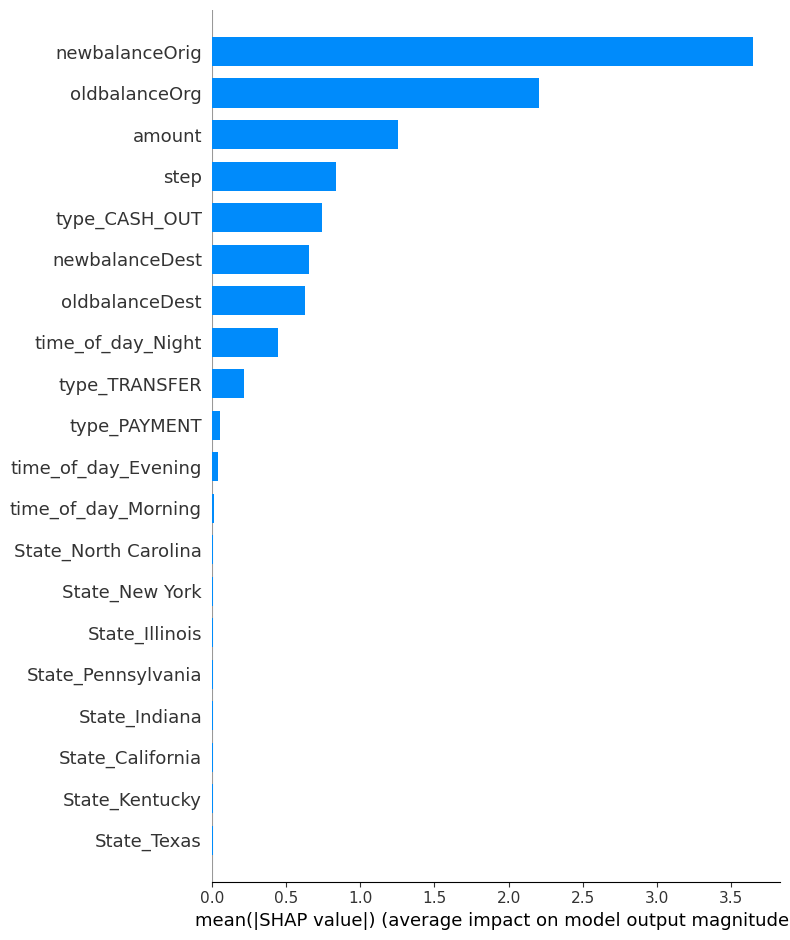

```
Generating SHAP Force Plot for sample index 10...
```

```
Generating SHAP Dependence Plot for feature: num__amount...
```

[output not shown]

```python
import shap
import matplotlib.pyplot as plt

# Use CatBoost-specific SHAP TreeExplainer
print("\nInitializing SHAP Explainer for CatBoost...")
explainer = shap.TreeExplainer(catboost_model)

# Calculate SHAP values for the test set
print("\nCalculating SHAP Values...")
shap_values = explainer.shap_values(X_test)

# SHAP Summary Plot
print("\nGenerating SHAP Summary Plot...")
shap.summary_plot(shap_values, X_test, plot_type="bar")

# Visualize SHAP values for individual predictions
sample_index = 10  # Change this index to explain different samples
print(f"\nGenerating SHAP Force Plot for sample index {sample_index}...")

if isinstance(explainer.expected_value, list):
    expected_value = explainer.expected_value[0]
else:
    expected_value = explainer.expected_value

shap.force_plot(
    expected_value,
    shap_values[sample_index],  # Use correct indexing for SHAP values
    X_test.iloc[sample_index],
    matplotlib=True,
)

# SHAP Dependence Plot for a specific feature
feature_to_plot = "num__amount"  # Change this to another feature for different plots
print(f"\nGenerating SHAP Dependence Plot for feature: {feature_to_plot}...")
shap.dependence_plot(feature_to_plot, shap_values, X_test)
```

[output not shown]

### **SHAP Analysis with Force Plot and Dependence Plot**

#### **General SHAP Insights**

- **Transparency**:
  - These plots enhance interpretability, helping identify how individual features and their interactions contribute to predictions.
- **Actionable Insights**:
  - Features like **time_of_day_Night** and **transaction types (type_CASH_OUT)** play critical roles in fraud detection.
  - Understanding interactions between features (e.g., amount and type_CASH_OUT) can guide feature engineering or business rules.
- **Fraud Detection Applications**:
  - For smaller amounts or night-time transactions, higher SHAP values suggest the need for additional scrutiny, as these patterns are more indicative of fraud.

```
Available Features in X_test:
Index(['amount', 'oldbalanceOrg', 'newbalanceOrig', 'isFlaggedFraud', 'step',
       'newbalanceDest', 'oldbalanceDest', 'type_CASH_OUT', 'type_DEBIT',
       'type_PAYMENT', 'type_TRANSFER', 'time_of_day_Evening',
       'time_of_day_Morning', 'time_of_day_Night', 'State_Alaska',
       'State_Arizona', 'State_Arkansas', 'State_California', 'State_Colorado',
       'State_Connecticut', 'State_Delaware', 'State_Florida', 'State_Georgia',
       'State_Hawaii', 'State_Idaho', 'State_Illinois', 'State_Indiana',
       'State_Iowa', 'State_Kansas', 'State_Kentucky', 'State_Louisiana',
       'State_Maine', 'State_Maryland', 'State_Massachusetts',
       'State_Michigan', 'State_Minnesota', 'State_Mississippi',
       'State_Missouri', 'State_Montana', 'State_Nebraska', 'State_Nevada',
       'State_New Hampshire', 'State_New Jersey', 'State_New Mexico',
       'State_New York', 'State_North Carolina', 'State_North Dakota',
       'State_Ohio', 'State_Oklahoma', 'State_Oregon', 'State_Pennsylvania',
       'State_Rhode Island', 'State_South Carolina', 'State_South Dakota',
       'State_Tennessee', 'State_Texas', 'State_Utah', 'State_Vermont',
       'State_Virginia', 'State_Washington', 'State_West Virginia',
       'State_Wisconsin', 'State_Wyoming'],
      dtype='object')

Generating SHAP Dependence Plot for feature: amount...
```

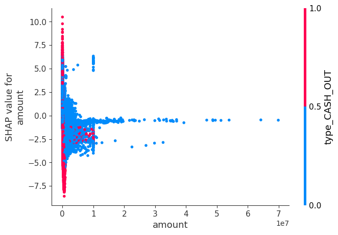

```python
# Print all available feature names in X_test
print("\nAvailable Features in X_test:")
print(X_test.columns)

# Update the feature_to_plot with a valid feature name
feature_to_plot = "amount"  # Replace this with the correct column name from the printed list

print(f"\nGenerating SHAP Dependence Plot for feature: {feature_to_plot}...")

# Generate the dependence plot with the corrected feature name
shap.dependence_plot(feature_to_plot, shap_values, X_test)
```

```python
print("SHAP values shape:", shap_values.shape)
print("X_test shape:", X_test.shape)
```

```
SHAP values shape: (263111, 63)
X_test shape: (263111, 63)
```

```python
print("Unique values in 'amount':", X_test['amount'].unique())
```

```
Unique values in 'amount': [  7443.43  10000.24 520937.07 ...   3284.91  73197.48  78954.1 ]
```

```
Generating SHAP Summary Plot...
```

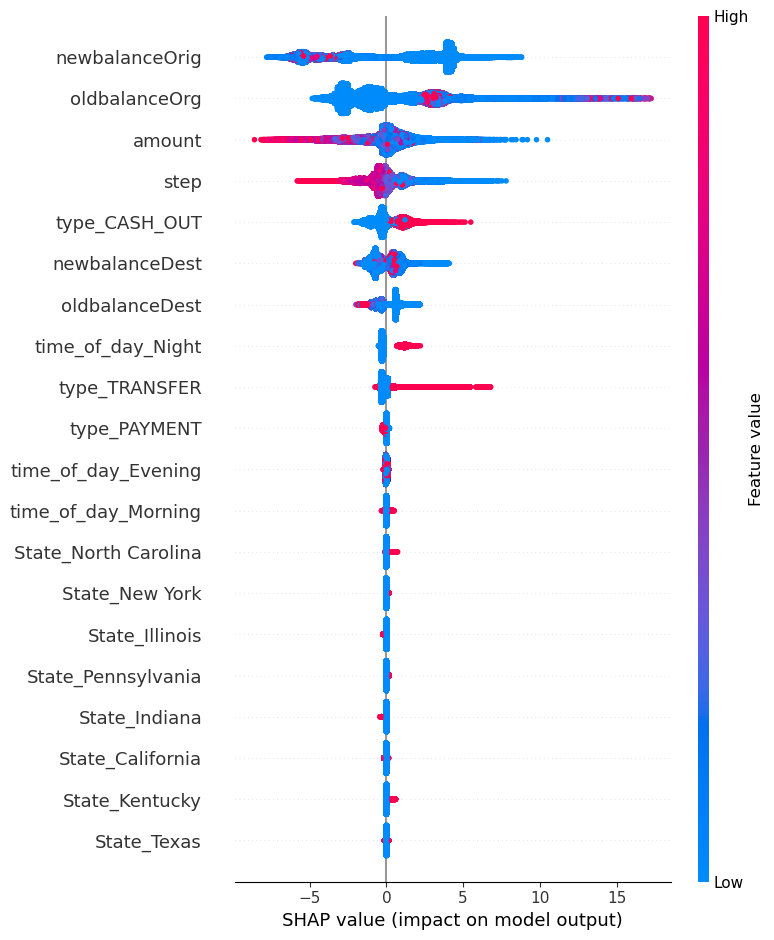

```python
# SHAP Summary Plot
print("Generating SHAP Summary Plot...")
shap.summary_plot(shap_values, X_test)
```

#### **Why This Is Useful**

- **Interpretability**:
  - The plot makes it clear how individual features influence the model’s predictions, bridging the gap between complex machine learning models and human understanding.
- **Feature Engineering**:
  - Identifying highly impactful features can guide efforts to refine or add new variables for improving model performance.

```python
# SHAP Force Plot for Local Interpretations
sample_index = 10  # Choose a specific test sample to interpret
print(f"\nGenerating SHAP Force Plot for sample index {sample_index}...")

shap.force_plot(
    base_value=explainer.expected_value,
    shap_values=shap_values[sample_index],
    features=X_test.iloc[sample_index],
    feature_names=X_test.columns,
    matplotlib=True
)
```

[output not shown]

```
Generating SHAP Force Plot for sample index 10...
```

```
Generating SHAP Summary Plot...
```

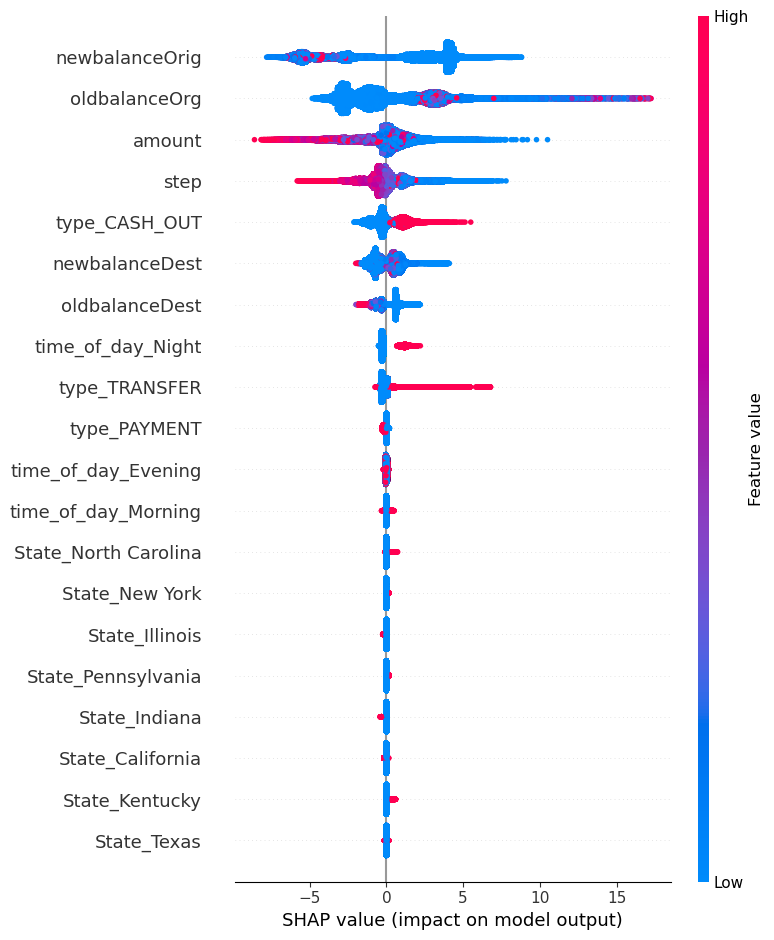

```python
# SHAP Summary Plot
print("Generating SHAP Summary Plot...")
shap.summary_plot(shap_values, X_test)
```

```python
# SHAP Force Plot for Local Interpretations
sample_index = 10  # Change this index to analyze different samples
print(f"\nGenerating SHAP Force Plot for sample index {sample_index}...")

shap.force_plot(
    base_value=explainer.expected_value,
    shap_values=shap_values[sample_index],
    features=X_test.iloc[sample_index],
    feature_names=X_test.columns,
    matplotlib=True
)
```

[output not shown]

```
Generating SHAP Force Plot for sample index 10...
```

```
Generating SHAP Dependence Plot for feature: amount...
```

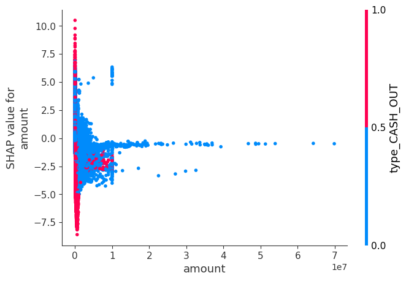

```python
# SHAP Dependence Plot
feature_to_plot = "amount"  # Replace with the feature name you want to analyze
print(f"\nGenerating SHAP Dependence Plot for feature: {feature_to_plot}...")
shap.dependence_plot(feature_to_plot, shap_values, X_test)
```

```python
# Calculate mean absolute SHAP values for each feature
mean_abs_shap_values = pd.DataFrame({
    'Feature': X_test.columns,
    'Mean_Absolute_SHAP_Value': np.abs(shap_values).mean(axis=0)
}).sort_values(by='Mean_Absolute_SHAP_Value', ascending=False)

# Top 10 important features
print("\nTop 10 Features by SHAP Value (Global Importance):")
print(mean_abs_shap_values.head(10))
```

```
Top 10 Features by SHAP Value (Global Importance):
              Feature  Mean_Absolute_SHAP_Value
2      newbalanceOrig                  3.646211
1       oldbalanceOrg                  2.203511
0              amount                  1.255044
4                step                  0.839119
7       type_CASH_OUT                  0.742726
5      newbalanceDest                  0.657398
6      oldbalanceDest                  0.631414
13  time_of_day_Night                  0.447159
10      type_TRANSFER                  0.216774
9        type_PAYMENT                  0.055400
```

```python
# Select a sample index to analyze
sample_index = 10  # Change this index to analyze another sample
sample_shap_values = shap_values[sample_index]

# Create a DataFrame to display feature contributions
local_shap_df = pd.DataFrame({
    'Feature': X_test.columns,
    'SHAP_Value': sample_shap_values
}).sort_values(by='SHAP_Value', ascending=False)

print(f"\nSHAP Values for Prediction at Index {sample_index}:")
print(local_shap_df.head(10))
```

```
SHAP Values for Prediction at Index 10:
                Feature  SHAP_Value
1         oldbalanceOrg    2.750442
0                amount    0.300984
11  time_of_day_Evening    0.057501
9          type_PAYMENT    0.008553
25       State_Illinois    0.007259
26        State_Indiana    0.003761
35      State_Minnesota    0.003724
55          State_Texas    0.003199
47           State_Ohio    0.001612
61      State_Wisconsin    0.001092
```

#### **Table Description**

- This table ranks the top 10 features by their **mean absolute SHAP value**, which quantifies their overall importance in influencing the model's predictions.
- The higher the **Mean Absolute SHAP Value**, the greater the average contribution of that feature to the model's decisions.

```python
# Summarize SHAP values for a specific feature
feature_to_analyze = "amount"  # Change this to analyze another feature
feature_shap_values = shap_values[:, X_test.columns.get_loc(feature_to_analyze)]

print(f"\nDependence Summary for Feature: {feature_to_analyze}")
print(f"Mean SHAP Value: {np.mean(feature_shap_values)}")
print(f"Median SHAP Value: {np.median(feature_shap_values)}")
print(f"Min SHAP Value: {np.min(feature_shap_values)}")
print(f"Max SHAP Value: {np.max(feature_shap_values)}")
```

```
Dependence Summary for Feature: amount
Mean SHAP Value: -0.1590104647438564
Median SHAP Value: 0.09935050738430434
Min SHAP Value: -8.590958576991001
Max SHAP Value: 10.4961963813414
```

## Interpretation and Results

#### **Project Overview**

In this analysis, we explored fraud detection using various machine learning models, evaluated their performance, and interpreted the results to understand the significance of features and patterns in fraudulent transactions. The primary goal was to identify critical fraud indicators and build a reliable model to predict fraudulent transactions accurately.

#### **Evaluation of Current Models**

1. **Model Performance**:
   - While XGBoost outperformed other models, the marginal difference in performance with Random Forest suggests both models are effective for this dataset.
   - Logistic Regression highlighted the limitations of linear models for highly imbalanced and complex datasets.
2. **Parameter Tuning**:
   - Grid Search CV did not yield significant improvements, suggesting that the current feature set might not fully capture the complexity of fraud detection.

#### **Key Observations**

- The **existing features** provide valuable insights but might not be sufficient for further performance gains.
- SHAP analysis revealed the transparency of the models, aligning their predictions with domain knowledge and emphasizing the importance of interpretability.

#### **SHAP Analysis**

- SHAP visualizations provided global and local interpretability for the models:
  - **Summary Plot**: Ranked features by their global importance, confirming the significance of balance, amount, and transaction type features.
  - **Dependence Plot**: Showed strong interactions between `amount` and categorical features like `type_CASH_OUT`.
  - **Force Plot**: Explained individual predictions, offering transparency in the decision-making process.

### **Final Takeaway**

This project provided a robust understanding of fraudulent transaction patterns and effective modeling techniques. XGBoost stood out as the optimal model, offering both high accuracy and interpretability. While current models perform well, incorporating more features and iterating through the lifecycle will enhance predictions and provide actionable insights for fraud prevention strategies.

# References

- data- https://www.kaggle.com/datasets/rupakroy/online-payments-fraud-detection-dataset
- book- Hands-on Machine Learning with Scikit Learn Tensorflow and Keras O'Riely
- XgBoost-https://medium.com/@jyotsna.a.choudhary/mastering-xgboost-a-technical-guide-for-intermediate-machine-learning-practitioners-f7ad167c6865
- Research Paper - A Unified Approach to Interpreting Model Predictions https://arxiv.org/abs/1705.07874
- EDA-https://medium.com/@pabbakavya123/a-comprehensive-guide-on-exploratory-data-analysis-eda-ab38f33d6abc